# Prosper Loan Data Exploration

## Investigation Overview

In this project I will investigate what features are best in prediction of the borrower interest rate for the loan, borrowers prosper score and credit grade.

I will investigate from simple univariate relationships up to multivariate relationships.

## Dataset Overview

There are 113937 loans in the dataset with 81 features for each loan, including borrower's annual percentage rate (APR), status, borrowed amount, debt, etc. I kept only 24 features which I will use in exploratory data analysis.

```python
# import all packages and set plots to be embedded inline
import numpy as np
import pandas as pd
import matplotlib.pyplot as plt
import seaborn as sb

%matplotlib inline

# suppress warnings from final output
import warnings
warnings.simplefilter("ignore")
```

```python
# load in the dataset into a pandas dataframe
df_loans = pd.read_csv('prosperLoanData.csv')
```

```python
#
df_loans_copy=df_loans.copy()
#list of columns to drop
columns=['ListingNumber', 'ListingCreationDate', 'EstimatedReturn',
'ClosedDate', 'BorrowerAPR', 'LenderYield', 'CurrentlyInGroup', 'GroupKey', 'DateCreditPulled', 'EstimatedEffectiveYield',
'CreditScoreRangeLower', 'CreditScoreRangeUpper', 'FirstRecordedCreditLine', 'CurrentCreditLines', 'OpenCreditLines', 'TotalCreditLinespast7years',
 'OpenRevolvingAccounts', 'OpenRevolvingMonthlyPayment', 'AmountDelinquent', 'PublicRecordsLast10Years'
,'PublicRecordsLast12Months', 'RevolvingCreditBalance', 'TotalTrades', 'TradesNeverDelinquent (percentage)',
'TradesOpenedLast6Months', 'IncomeVerifiable', 'LoanKey', 'TotalProsperLoans', 'TotalProsperPaymentsBilled'
, 'OnTimeProsperPayments', 'ProsperPaymentsLessThanOneMonthLate', 'ProsperPaymentsOneMonthPlusLate',
'ProsperPrincipalBorrowed', 'ProsperPrincipalOutstanding', 'ScorexChangeAtTimeOfListing', 'LoanCurrentDaysDelinquent',
'LoanFirstDefaultedCycleNumber', 'LoanMonthsSinceOrigination', 'LoanNumber', 'BorrowerState',
'LoanOriginationQuarter', 'MemberKey', 'PercentFunded', 'Recommendations', 'InvestmentFromFriendsCount',
'InvestmentFromFriendsAmount', 'Investors', 'ProsperRating (numeric)', 'CurrentDelinquencies', 'TotalInquiries']
df_loans_copy.drop(columns, axis=1, inplace=True)
columns_LP=df_loans_copy.filter(regex=("LP.*")).columns
df_loans_copy.drop(columns_LP, axis=1,inplace=True)
```

```python
# data wrangling, removing diamonds with inconsistent or missing data.
# rename the columns
df_loans_copy.rename(columns={'ListingCategory (numeric)':'ListingCategory', 'ProsperRating (Alpha)':'ProsperRating'}, inplace=True)
df_loans_copy.LoanOriginationDate=pd.to_datetime(df_loans_copy.LoanOriginationDate)
df_loans_copy = df_loans_copy.replace(to_replace ='Past Due.*', value = 'Past Due', regex = True)
```

```python
#group LoanOriginationDate into years
bin_edges=pd.date_range('2005-11-15 00:00:00', freq='Y', periods=10)
bin_names=['2006', '2007','2008','2009','2010','2011', '2012','2013','2014']
df_loans_copy['Year']=pd.cut(df_loans_copy.LoanOriginationDate, bins=bin_edges, labels=bin_names)
```

## Distribution of Borrower Rate

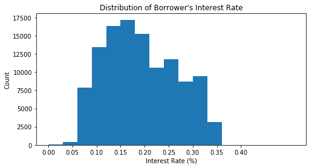

```python
# univariate plot of borrower rate. Since it is a numeric variable, the histogram is created.
plt.figure(figsize = [8, 4])
bin_edges=np.arange(0, df_loans_copy['BorrowerRate'].max()+0.03,0.03)
plt.hist(data = df_loans_copy, x = 'BorrowerRate', bins=bin_edges)
#
plt.xlabel("Interest Rate (%)")
plt.ylabel('Count')
plt.title("Distribution of Borrower's Interest Rate");
plt.xticks(np.arange(0, 0.45, 0.05));
```

## Distribution of Credit Grade

The distribution of credit grade is normal and is centered at C. The value 'NC' is very small, meaning only a small number of people didn't get their credit prior 2009.

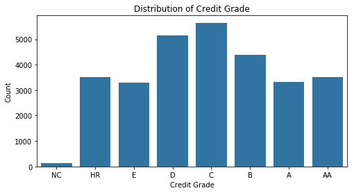

```python
plt.figure(figsize = [8, 4])
base_color = sb.color_palette()[0]
level_order = ['NC', 'HR', 'E', 'D', 'C', 'B', 'A', 'AA']
ordered_cat = pd.api.types.CategoricalDtype(ordered = True, categories = level_order)
df_loans_copy['CreditGrade'] = df_loans_copy['CreditGrade'].astype(ordered_cat)
sb.countplot(data = df_loans_copy, x = 'CreditGrade', color = base_color);
plt.title("Distribution of Credit Grade")
plt.xlabel("Credit Grade")
plt.ylabel('Count')
plt.show();
```

## Distribution of Prosper Score

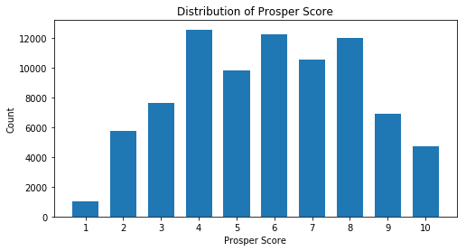

```python
plt.figure(figsize = [8, 4])
bin_edges = np.arange(0.5, 10.5+1, 1)
plt.hist(data=df_loans_copy, x='ProsperScore',bins = bin_edges, rwidth = 0.7)
plt.xticks(np.arange(1, 10+1, 1))
plt.xlabel('Prosper Score')
plt.ylabel('Count')
plt.title("Distribution of Prosper Score");
```

## Borrower Rate vs. Credit Grade

The median borrower's interest rate decreases with the increase of credit grade. Some bimodality is seen in credit grades HR, E and D. Credit grades B, A and AA are skewed to the right. The higher the credit grade the more data are clustered around the median.

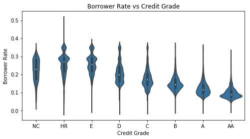

```python
plt.figure(figsize = [8, 4])
level_order = ['NC', 'HR', 'E', 'D', 'C', 'B', 'A', 'AA']
ordered_cat = pd.api.types.CategoricalDtype(ordered = True, categories = level_order)
df_loans_copy['CreditGrade'] = df_loans_copy['CreditGrade'].astype(ordered_cat)
base_color = sb.color_palette()[0]
sb.violinplot(data = df_loans_copy, x = 'CreditGrade', y = 'BorrowerRate', color=base_color)
plt.xlabel('Credit Grade')
plt.ylabel('Borrower Rate')
plt.title("Borrower Rate vs Credit Grade");
```

## Borrower Rate vs. Prosper Score

The plot below shows that the higher the prosper score the lower is the borrower rate.

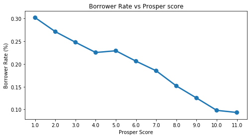

```python
plt.figure(figsize = [8, 4])
base_color = sb.color_palette()[0]
sb.pointplot(data = df_loans_copy, x = 'ProsperScore', y = 'BorrowerRate', color=base_color)
plt.xlabel('Prosper Score')
plt.ylabel('Borrower Rate (%)')
plt.title("Borrower Rate vs Prosper score");
```

## Prosper Score vs Estimated Loss

The median of the prosper score is increasing with the decrease of estimated loss. The higher the prosper score more values are clustered around the median.

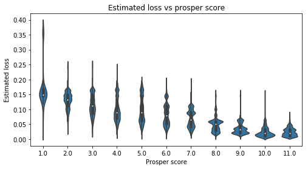

```python
plt.figure(figsize = [8, 4])
base_color = sb.color_palette()[0]
sb.violinplot(data = df_loans_copy, x = 'ProsperScore', y = 'EstimatedLoss', color = base_color);
plt.xlabel('Prosper score')
plt.ylabel('Estimated loss')
plt.title("Estimated loss vs prosper score");
```

## Prosper Score vs Stated Monthly Income and Debt-To-Income Ratio

Higher monthly income and lower debt-to-income ration gives better prosper score.

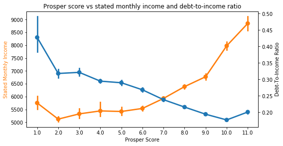

```python
fig, ax1 = plt.subplots(figsize = [8,4])
color = 'tab:orange'
sb.pointplot(data = df_loans_copy, x = 'ProsperScore', y = 'StatedMonthlyIncome', ax = ax1, color=color)
ax1.set_xlabel('Prosper Score')
ax1.set_ylabel('Stated Monthly Income', color=color)
ax2 = ax1.twinx()
sb.pointplot(data = df_loans_copy, x = 'ProsperScore', y = 'DebtToIncomeRatio', ax = ax2)
ax2.set_ylabel('Debt-To-Income Ratio')
fig.tight_layout()
plt.title("Prosper score vs stated monthly income and debt-to-income ratio");
plt.show()
```

## Credit Grade vs Available Bankcard Credit and Bankcard Utilization

The higher available bankcard credit, the higher credit score. The lower bankcard utilization gives the higher credit grade. Low bankcard utilization means only the small percentage of a borrower’s total available credit is currently being utilized.

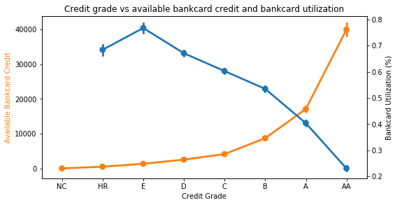

```python
fig, ax1 = plt.subplots(figsize = [8,4])
color = 'tab:orange'
sb.pointplot(data = df_loans_copy, x = 'CreditGrade', y = 'AvailableBankcardCredit', ax = ax1, color=color)
ax1.set_ylabel('Available Bankcard Credit', color=color)
ax2 = ax1.twinx()
sb.pointplot(data = df_loans_copy, x = 'CreditGrade', y = 'BankcardUtilization', ax = ax2)
ax2.set_ylabel('Bankcard Utilization (%)')
fig.tight_layout()
ax1.set_xlabel('Credit Grade')
plt.title("Credit grade vs available bankcard credit and bankcard utilization");
plt.show()
```

## Credit Grade vs Inquiries Last 6 Months and Loan Original Amount

The smaller number of credit inquiries, the better is credit score. By raising credit score the higher original loan amount can be approved.

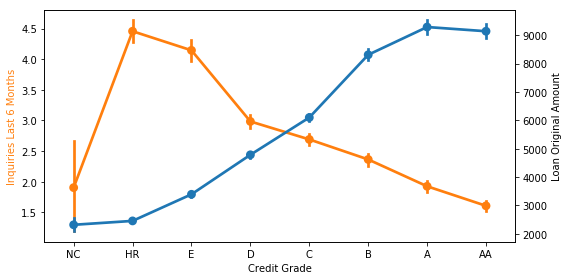

```python
fig, ax1 = plt.subplots(figsize = [8,4])
color = 'tab:orange'
sb.pointplot(data = df_loans_copy, x = 'CreditGrade', y = 'InquiriesLast6Months', ax = ax1, color=color)
ax1.set_ylabel('Inquiries Last 6 Months', color=color)
ax2 = ax1.twinx()
sb.pointplot(data = df_loans_copy, x = 'CreditGrade', y = 'LoanOriginalAmount', ax = ax2)
ax2.set_ylabel('Loan Original Amount')
ax1.set_xlabel('Credit Grade')
fig.tight_layout()
plt.show()
```

## Credit Grade vs Loan Original Amount

Property ownership increases loan original amount especially for higher credit grades.

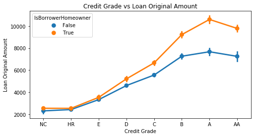

```python
base_color = sb.color_palette()[0]
plt.figure(figsize = [8, 4])
sb.pointplot(data = df_loans_copy, x = 'CreditGrade', y = 'LoanOriginalAmount', hue='IsBorrowerHomeowner')
plt.xlabel('Credit Grade')
plt.ylabel('Loan Original Amount')
plt.title("Credit Grade vs Loan Original Amount");
```

## Credit Grade and Loan Original Amount for Selected Loan Status

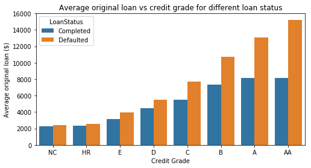

```python
plt.figure(figsize = [8, 4])
data=df_loans_copy[df_loans_copy['LoanStatus'].isin(['Completed', 'Defaulted', 'Current', 'Past Due'])]
ct_counts=data.groupby(['CreditGrade','LoanStatus'])['LoanOriginalAmount'].mean()
ct_counts=ct_counts.reset_index(name='LoanOriginalMean')
ct_counts
sb.barplot(x="CreditGrade", y="LoanOriginalMean", hue="LoanStatus", data=ct_counts);
plt.xlabel('Credit Grade')
plt.ylabel('Average original loan ($)')
plt.title("Average original loan vs credit grade for different loan status");
```

## Year vs Loan Original Status for Different Loan Statuses

The loans originated before 2009 were either completed or defaulted. After 2009 only a small number of loans were defaulted. The number of current loans increased significantly reaching its peak in 2013.

[figure not shown]

```python
plt.figure(figsize = [8, 4])
base_color = sb.color_palette()[0]
data=df_loans_copy[df_loans_copy['LoanStatus'].isin(['Completed', 'Defaulted', 'Current', 'Past Due'])]
ct_counts=data.groupby(['CreditGrade','LoanStatus'])['LoanOriginalAmount'].mean()
ct_counts=ct_counts.reset_index(name='LoanOriginalMean')
sb.countplot(data = data, x = 'Year', hue="LoanStatus");
plt.xlabel('Year')
plt.ylabel('Average original loan ($)')
plt.title("Average original loan for different loan status");
```